# Explore Fourier and Wavelets Interactively

Download notebook[co Open in Colab](https://colab.research.google.com/github/gpeyre/numerical-tours/blob/master/python/introduction_4_fourier_wavelets_interactive.ipynb)

# Explore Fourier and Wavelets Interactively

Use interactive controls to vary how many transform coefficients an image keeps. Compare reconstruction quality across Fourier and wavelet representations, and connect abrupt visual changes with the coefficients being discarded.

## Run this tour

Run the cells in order with a Python 3 kernel. The first cell locates the companion data and toolbox and installs missing dependencies when needed. All worked examples include their implementation directly in this notebook. Random seeds make comparisons reproducible; you can change them to explore other samples.

```python
# Locate the companion toolbox locally, or fetch it for a standalone/Colab copy.
from pathlib import Path
import importlib.util
import os
import subprocess
import sys

working = Path.cwd()
candidates = [working, working / "python", working.parent / "python"]
python_dir = next((p for p in candidates if (p / "nt_toolbox").is_dir()), None)
if python_dir is None:
    checkout = working / "numerical-tours-support"
    if not checkout.exists():
        subprocess.run(
            [
                "git",
                "clone",
                "--depth",
                "1",
                "--branch",
                "master",
                "https://github.com/gpeyre/numerical-tours.git",
                str(checkout),
            ],
            check=True,
        )
    python_dir = checkout / "python"
os.chdir(python_dir)
if str(python_dir) not in sys.path:
    sys.path.insert(0, str(python_dir))
requirements = python_dir / "requirements.txt"
if any(
    importlib.util.find_spec(name) is None
    for name in [
        "numpy",
        "scipy",
        "matplotlib",
        "skimage",
        "sklearn",
        "pywt",
        "ipywidgets",
        "cvxpy",
        "skfmm",
        "autograd",
        "progressbar",
        "celer",
    ]
):
    subprocess.run(
        [sys.executable, "-m", "pip", "install", "-r", str(requirements)], check=True
    )

import numpy as np
import matplotlib.pyplot as plt

np.random.seed(0)
plt.rcParams.update(
    {
        "figure.figsize": (8, 4),
        "figure.dpi": 100,
        "axes.spines.top": False,
        "axes.spines.right": False,
        "font.size": 11,
        "image.cmap": "gray",
    }
)
%matplotlib inline
```

This notebook compares 3 basic ways to approximate (and thus in some loose sense "compress") images:

```python
import numpy as np
import matplotlib.pyplot as plt
from PIL import Image
import warnings
import pywt  # to compute wavelet transforms
```

```python
def preprocess(f, n):
    n0 = np.min(f.size)
    f = f.crop((0, 0, n0, n0))
    f = f.resize((n, n))
    f = np.array(f)
    f = np.clip(f / np.max(f.flatten()), 0, 1)
    return f
```

```python
n = 512
f = preprocess(Image.open("nt_toolbox/data/flowers.png").convert("RGB"), n)
```

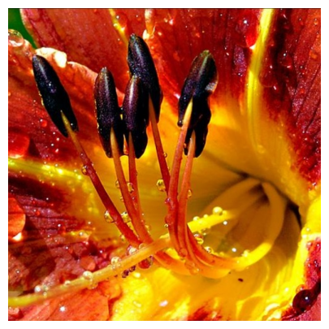

```python
plt.rcParams["figure.figsize"] = [8, 5]
plt.imshow(f)
plt.axis("off");
```

```python
def approx_pixels(f, r):
    p = int(n * np.sqrt(r))
    f = Image.fromarray(np.uint8(f * 255))
    f = f.resize((p, p), Image.NEAREST)
    f = f.resize((n, n), Image.NEAREST)
    f = np.array(f) / 255.0
    return np.clip(f, 0, 1)
```

```python
def approx_fourier(f, r):
    m = int(r * n * n)
    # compute a 1D indexing from low to high frequencies
    x = np.concatenate((np.arange(0, int(n / 2)), np.arange(-int(n / 2), 0)))
    D = x[:, None] ** 2 + x[None, :] ** 2
    mask = D < np.sort(D.flatten())[m]
    # inverse the masked FFT
    F = np.fft.fft2(f, axes=(0, 1))
    F = F * mask[:, :, None]
    fM = np.real(np.fft.ifft2(F, axes=(0, 1)))
    return np.clip(fM, 0, 1), np.fft.fftshift(mask)
```

```python
def approx_wavelets(f, r):
    m = int(r * n * n)
    wavetype = "bior3.5"
    nlvel = int(np.floor(np.log2(n)) - 3)
    f1 = np.zeros(f.shape)
    for k in range(3):
        with warnings.catch_warnings():
            warnings.simplefilter(
                "ignore"
            )  # pywlet issue a warning for too low level decomposition
            fW = pywt.wavedec2(f[:, :, k], wavetype, level=nlvel)
        # turn coefficient into a convenient array
        fWI, coeff_slices = pywt.coeffs_to_array(fW)
        D = np.sort(np.abs(fWI.flatten()))  # sorted coefficients magnitude
        fWI = fWI * (abs(fWI) > D[-m - 1])  # threshold
        fW1 = pywt.array_to_coeffs(fWI, coeff_slices, output_format="wavedec2")
        f1[:, :, k] = pywt.waverec2(fW1, wavetype)
    mask = abs(fWI) > D[-m - 1]
    return np.clip(np.array(f1), 0, 1), mask
```

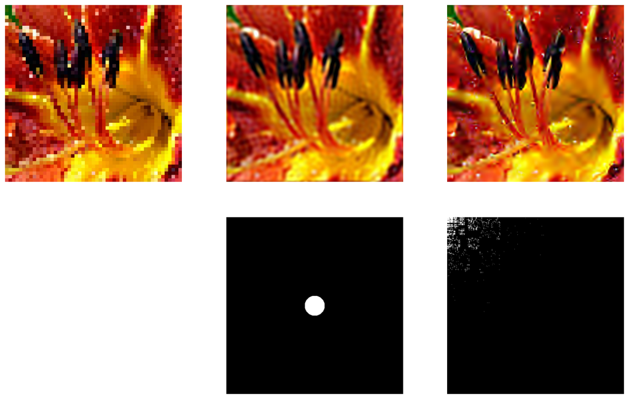

```python
def render_display(r):
    fP = approx_pixels(f, r)
    fF, mF = approx_fourier(f, r)
    fW, mW = approx_wavelets(f, r)
    plt.rcParams["figure.figsize"] = [16, 10]
    plt.subplot(2, 3, 1)
    plt.imshow(fP)
    plt.axis("off")
    plt.subplot(2, 3, 2)
    plt.imshow(fF)
    plt.axis("off")
    plt.subplot(2, 3, 3)
    plt.imshow(fW)
    plt.axis("off")
    plt.subplot(2, 3, 5)
    plt.imshow(mF)
    plt.axis("off")
    plt.subplot(2, 3, 6)
    plt.imshow(mW)
    plt.axis("off")


r = 0.01  # compressio ratio
render_display(r)
```

```python
from ipywidgets import interact, interactive, fixed, interact_manual
import ipywidgets as widgets
```

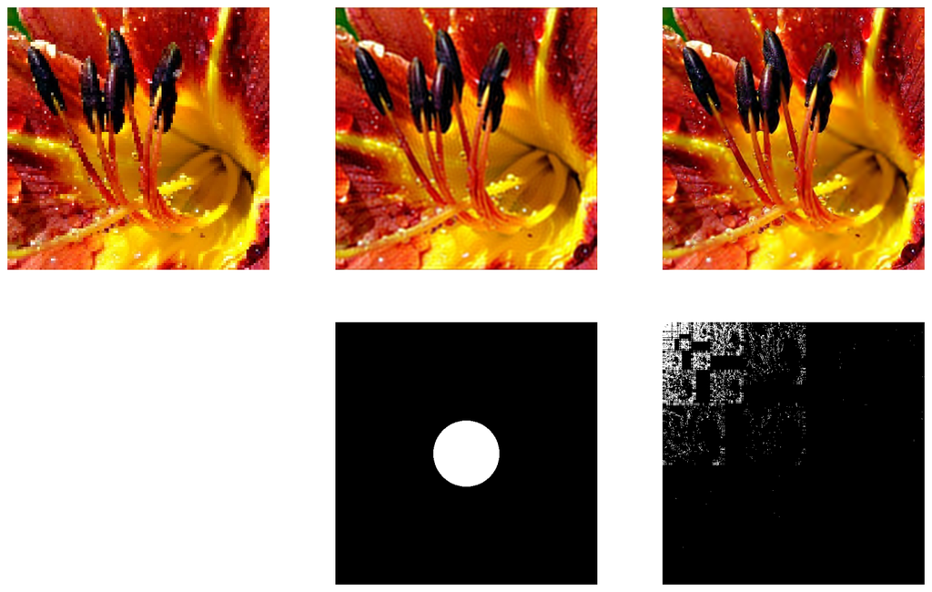

```python
@interact(r=(0.01 / 2, 0.1, 0.01 / 2))
def h(r=0.05):
    render_display(r)
```

## References and further reading

- Stéphane Mallat. [A Wavelet Tour of Signal Processing: The Sparse Way](https://www.di.ens.fr/~mallat/biblio.html). 2009, 3rd ed., Academic Press. Multiresolution analysis, sparse approximation, and wavelet algorithms.
- Ingrid Daubechies. [Ten Lectures on Wavelets](https://doi.org/10.1137/1.9781611970104). 1992, SIAM. Compactly supported orthogonal wavelets and their regularity.
- Gabriel Peyré. [Advanced Signal, Image and Surface Processing](https://www.numerical-tours.com/book/AdvancedSignalProcessing.pdf). 2010, course notes. A mathematical companion to the Numerical Tours.
- David L. Donoho. [De-noising by Soft-Thresholding](https://doi.org/10.1109/18.382009). 1995, IEEE Transactions on Information Theory 41(3), 613–627. Why shrinkage of wavelet coefficients suppresses noise.
- Pauli Virtanen et al.. [SciPy 1.0: Fundamental Algorithms for Scientific Computing in Python](https://doi.org/10.1038/s41592-019-0686-2). 2020, Nature Methods 17, 261–272. The numerical routines used for transforms, interpolation, and optimization.